# Session 1, Notebook 3

## 6: Reading a voltage using Python

Now we can look at how to use the combined power of Arduino and Python to make measurements for us (to some extent...)!

- Open the `AnalogReadVoltage` example sketch that we were using previously in the Arduino IDE. We are going to make a slight modification to it based on what we have learned about serial interfacing.

In order that our Python code is able to discard any 'old' data that happens to be hanging around 'in the cable' (actually in the transmission buffer memory of the Arduino or input buffer memory of the PC) from previous measurements, and ensure that we always gather 'new' data, we will program the Arduino to send a distinctive message on startup. We will then empty the buffer and discard it with our Python code by reading until we find the same distinctive message.

```
// the setup routine runs once when you press reset:
void setup() {
  Serial.begin(9600); // initialize serial communication at 9600 bits per second:
  Serial.write("Dear Python, Good day to you! Yours sincerely, Arduino"); // A distinctive startup message
}

// the loop routine runs over and over again forever:
void loop() {
  // read the input on analog pin 0:
  int sensorValue = analogRead(A0);
  // Convert the analog reading (which goes from 0 - 1023) to a voltage (0 - 5V):
  float voltage = sensorValue * (5.0 / 1023.0);
  // print out the value you read:
  Serial.println(voltage);
}
```

- Save this with a distinctive filename, say `AnalogReadVoltage_distinctive.ino` then verify and upload it to the Arduino Uno.
- Create a **new** Jupyter Notebook and name it appropriately.

```python
import serial #requires pySerial module to be installed

########################################################################
#
# Change this value to the serial port where your Arduino is connected
#
serial_port = 'COM16' # Windows
# serial_port = '/dev/tty####' # Linux
# serial_port = '/dev/cu.####' # Mac
```

After importing the pySerial module and setting an appropriate value for the serial port address above, now we can write some Python code to:

- Connect to our Arduino with appropriate settings (and so causing `setup()` to run)
- Search for our distinctive startup message to clear out any old data from the buffer memory
- Read in a voltage value output by `loop()` and store it as `data`
- Print `data` and its type

```python
with serial.Serial(port=serial_port, baudrate=9600, timeout=2) as arduino:
    print(arduino.read_until(b'Yours sincerely, Arduino'))
    data = arduino.read_until(b'\r\n')
    # Serial.println() terminates messages with '\r\n', and it is a bytearray!

print('data;', data,
      ', of type', type(data))
```

```
b'30Dear Python, Good day to you! Yours sincerely, Arduino'
data; b'3.29\r\n' , of type <class 'bytes'>
```

Note that `data` is still a bytearray, and still has the termination characters appended. To turn the bytearray into a string datatype we can use the `.decode()` method of the bytes datatype; the default behaviour is to decode from 'bytes' to a 'utf-8' encoded string (in Python 3 this is the standard variety of 'string'):

```python
print('data.decode();', data.decode(),
      ', of type', type(data.decode()))
```

```
data.decode(); 3.29
 , of type <class 'str'>
```

Note that this 'works' even if no value is returned from the Arduino, i.e. `data = b''`.

There is still a slightly odd behaviour as the `\r\n` have the combined effect of starting a new line at the end of our numerical value... These 'non-printing' characters can be removed from the ends of the string using the `.strip()` method of the string datatype:

```python
print('data.decode().strip();', data.decode().strip(),
      ', of type', type(data.decode().strip()))
```

```
data.decode().strip(); 3.29 , of type <class 'str'>
```

Again, note that this 'works' even if `data.decode() = ''`.

Now that the result looks like a number, we can turn it into a numeric datatype using, for example, the `float()` function:

```python
print('float(data.decode().strip());', float(data.decode().strip()),
      ', of type', type(float(data.decode().strip())))
```

```
float(data.decode().strip()); 3.29 , of type <class 'float'>
```

Now we need to consider what happens if there is no data returned, or if the data is corrupted such that it returns a string that can't be converted into a numeric value... In that case the call to `float()` will fail, giving a `ValueError` exception, and crash our data acquisition code!

We can handle this by wrapping the type conversion in a `try` statement, and return a value of 0.0 (for example) if a `ValueError` exception occurs.

Putting all of this together we end up with:

```python
with serial.Serial(port=serial_port, baudrate=9600, timeout=2) as arduino:
    print(arduino.read_until(b'Yours sincerely, Arduino'))
    print('\n')
    data = arduino.read_until(b'\r\n')
    try:
        numeric_data = float(data.decode().strip())
    except ValueError:
        numeric_data = 0.0


print('numeric_data; ', numeric_data,
      ', of type', type(numeric_data))
```

```
b'.\r\n3.30\r\n3.30\r\n3.30\r\n3.30\r\n3.3030\r\n3.30\r\n3.30\r\n3.30\r\n3.30\r\n3.30\r\n3.30\r\n3.30\r\n3.30\r\n3.30\r\n3.30\r\n3.30\r\n3.30\r\n3.30\r\n3.30\r\n3.30\r\n3.30\r\n3.30\r\n3.30\r\n3.30\r\n3.30\r\n3.3030\r\n3.30\r\n3.30\r\n3.30\r\n3.30\r\n3.30\r\n3.30\r\n3.30\r\n3.30\r\n3.30\r\n3.30\r\n3…


numeric_data;  3.29 , of type <class 'float'>
```

It might be helpful to package this up in a simple function. We can set the various communications settings as default values for arguments of the function (use the appropriate value for `serial_port`!), and no longer need to print our startup message. We also include `import serial` within the function such that it is self-contained:

```python
def simple_read_arduino(serial_port='COM16', baud_rate=9600, timeout=2):
    import serial
    with serial.Serial(port=serial_port, baudrate=baud_rate, timeout=timeout) as arduino:
        arduino.read_until(b'Yours sincerely, Arduino') # no longer bother printing this!
        data = arduino.read_until(b'\r\n')
        try:
            numeric_data = float(data.decode().strip())
        except ValueError:
            numeric_data = 0.0
    return numeric_data

numeric_data = simple_read_arduino()

print('numeric_data; ', numeric_data,
      ', of type', type(numeric_data))
```

```
numeric_data;  3.3 , of type <class 'float'>
```

We can make some improvements:

- what if we want to make more than 1 reading?
- what if we know the data will be a different data-type (e.g. integer etc.)?
- what if we programmed the Arduino to use different termination characters, or a different startup-string?
- what if 0.0 is not an appropriate value to return if we encounter an error?

We can put all of these as arguments to the function (with appropriate default values), and we can make the function return a numpy array of values. To make our function easier to use, it takes in `terminator` and `startup_message` as normal strings and does the conversion to bytearrays internally, using the `encode()` method of the string datatype. Note that the function requires `import numpy` in the main code.

This looks a bit more complicated (it's not, really!); let's do a few tests of how it behaves.

```python
import numpy

def improved_read_arduino(number_readings=1, data_type=numpy.float32, error_value=numpy.NaN,
                          serial_port='COM16', baud_rate=9600, timeout=2,
                          terminator='\r\n', startup_message='Yours sincerely, Arduino'):

    if number_readings < 1: number_readings = 1 #need at least 1 reading
    numeric_data = numpy.zeros((number_readings,), dtype=data_type)
    import serial
    with serial.Serial(port=serial_port, baudrate=baud_rate, timeout=timeout) as arduino:
        arduino.read_until(startup_message.encode()) # string.encode() -> bytearray
        for i in range(number_readings):
            data = arduino.read_until(terminator.encode()) # string.encode() -> bytearray
            try:
                numeric_data[i] = data_type(data.decode().strip())
            except ValueError:
                numeric_data[i] = error_value
    return numeric_data
```

Calling this function without specifying any arguments should return a numpy array containing `number_readings=1` value of type `data_type=numpy.float32` (unless there is an error, in which case we return a value of `error_value=numpy.NaN` - 'not a number').

```python
numpy_value = improved_read_arduino()

print('numpy_value; ', numpy_value,
      ', of type', type(numpy_value))
print('numpy_value[0]; ', numpy_value[0],
      ', of type', type(numpy_value[0]))
```

```
numpy_value;  [3.29] , of type <class 'numpy.ndarray'>
numpy_value[0];  3.29 , of type <class 'numpy.float32'>
```

Now, try making multiple readings - say 10:

```python
numpy_values = improved_read_arduino(number_readings=10)

print('numpy_values; ', numpy_values,
      ', of type', type(numpy_values))
print('numpy_values[0]; ', numpy_values[0],
      ', of type', type(numpy_values[0]))
```

```
numpy_values;  [3.3  3.29 3.29 3.3  3.3  3.3  3.3  3.3  3.3  3.29] , of type <class 'numpy.ndarray'>
numpy_values[0];  3.3 , of type <class 'numpy.float32'>
```

Now we have some data that we can use! We have a set of readings, and, as trained scientists, we know how to present the result of such a set of measurements of the same quantity (and remember that trained scientists understand how to deal with significant figures better than numpy does!):

```
average value = 3.2970002 +/- 0.0014491362947450968 units
```

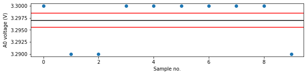

```python
%matplotlib inline
import matplotlib.pyplot as plt

def plot(data):
    mean = numpy.mean(data)
    std_error = numpy.std(data)/numpy.sqrt(len(data))
    print('average value =', mean, '+/-', std_error, 'units')

    plt.figure(figsize=(10,2))
    plt.plot(data, marker='o', linestyle='none')
    plt.axhline(mean-std_error, color='r')
    plt.axhline(mean, color='k')
    plt.axhline(mean+std_error, color='r')
    plt.xlabel('Sample no.'); plt.ylabel('A0 voltage (V)')
    plt.show()


plot(numpy_values)
```

Recall that the Arduino analog-to-digital converter (ADC) has a voltage resolution of about 5 mV, which you should find is roughly consistent with the spread of your data.

Simple code like this can easily be included in a bigger program to control data acquisition on a much larger scale!

**Save your notebooks and export them to HTML format (File -> Download as -> HTML).** Saving as HTML will include all outputs (including graphs etc.) in a 'frozen' format; keep a copy so that you can refer to it while completing the assessment assignment (or view it again later) and there is no chance that you can 'lose' the output by accidentally re-running code cells.